# 6. Description of attributes:

1 - fixed acidity: most acids involved with wine or fixed or nonvolatile (do not evaporate readily)

2 - volatile acidity: the amount of acetic acid in wine, which at too high of levels can lead to an unpleasant, vinegar taste

3 - citric acid: found in small quantities, citric acid can add ‘freshness’ and flavor to wines

4 - residual sugar: the amount of sugar remaining after fermentation stops, it’s rare to find wines with less than 1 gram/liter and wines with greater than 45 grams/liter are considered sweet

5 - chlorides: the amount of salt in the wine

6 - free sulfur dioxide: the free form of SO2 exists in equilibrium between molecular SO2 (as a dissolved gas) and bisulfite ion; it prevents microbial growth and the oxidation of wine

7 - total sulfur dioxide: amount of free and bound forms of S02; in low concentrations, SO2 is mostly undetectable in wine, but at free SO2 concentrations over 50 ppm, SO2 becomes evident in the nose and taste of wine

8 - density: the density of water is close to that of water depending on the percent alcohol and sugar content

9 - pH: describes how acidic or basic a wine is on a scale from 0 (very acidic) to 14 (very basic); most wines are between 3-4 on the pH scale

10 - sulphates: a wine additive which can contribute to sulfur dioxide gas (S02) levels, wich acts as an antimicrobial and antioxidant

11 - alcohol: the percent alcohol content of the wine

Output variable (based on sensory data): 12 - quality (score between 0 and 10)

**“He who knows nothing, loves nothing. He who can do nothing understands nothing. He who understands nothing is worthless. But he who understands also loves, notices, sees … The more knowledge is inherent in a thing, the greater the love.… Anyone who imagines that all fruits ripen at the same time as the strawberries knows nothing about grapes.” ― Paracelsus**

```r
library(tibble)
library(ggplot2)
library(EnvStats)
options(repr.plot.width=6, repr.plot.height=3)
white <- read.csv('./data/winequality-white.csv', sep=';')
red <- read.csv('./data/winequality-red.csv', sep=';')

# add categorical varialbles to both sets

add_type <- function(data, color){
  data <- add_column(data, color = color, .before = 'quality')}

red <- add_type(red, 'red')
white <- add_type(white, 'white')

# merge red wine and white wine datasets
data <- rbind(red, white)
```

```r
head(data, n =2)
```

| fixed.acidity | volatile.acidity | citric.acid | residual.sugar | chlorides | free.sulfur.dioxide | total.sulfur.dioxide | density | pH | sulphates | alcohol | color | quality |
| --- | --- | --- | --- | --- | --- | --- | --- | --- | --- | --- | --- | --- |
| 7.4 | 0.70 | 0 | 1.9 | 0.076 | 11 | 34 | 0.9978 | 3.51 | 0.56 | 9.4 | red | 5 |
| 7.8 | 0.88 | 0 | 2.6 | 0.098 | 25 | 67 | 0.9968 | 3.20 | 0.68 | 9.8 | red | 5 |

```r
# All num
str(data)
```

```
'data.frame':	6497 obs. of  13 variables:
 $ fixed.acidity       : num  7.4 7.8 7.8 11.2 7.4 7.4 7.9 7.3 7.8 7.5 ...
 $ volatile.acidity    : num  0.7 0.88 0.76 0.28 0.7 0.66 0.6 0.65 0.58 0.5 ...
 $ citric.acid         : num  0 0 0.04 0.56 0 0 0.06 0 0.02 0.36 ...
 $ residual.sugar      : num  1.9 2.6 2.3 1.9 1.9 1.8 1.6 1.2 2 6.1 ...
 $ chlorides           : num  0.076 0.098 0.092 0.075 0.076 0.075 0.069 0.065 0.073 0.071 ...
 $ free.sulfur.dioxide : num  11 25 15 17 11 13 15 15 9 17 ...
 $ total.sulfur.dioxide: num  34 67 54 60 34 40 59 21 18 102 ...
 $ density             : num  0.998 0.997 0.997 0.998 0.998 ...
 $ pH                  : num  3.51 3.2 3.26 3.16 3.51 3.51 3.3 3.39 3.36 3.35 ...
 $ sulphates           : num  0.56 0.68 0.65 0.58 0.56 0.56 0.46 0.47 0.57 0.8 ...
 $ alcohol             : num  9.4 9.8 9.8 9.8 9.4 9.4 9.4 10 9.5 10.5 ...
 $ color               : chr  "red" "red" "red" "red" ...
 $ quality             : int  5 5 5 6 5 5 5 7 7 5 ...
```

```r
summary(data)
```

```
 fixed.acidity    volatile.acidity  citric.acid     residual.sugar
 Min.   : 3.800   Min.   :0.0800   Min.   :0.0000   Min.   : 0.600
 1st Qu.: 6.400   1st Qu.:0.2300   1st Qu.:0.2500   1st Qu.: 1.800
 Median : 7.000   Median :0.2900   Median :0.3100   Median : 3.000
 Mean   : 7.215   Mean   :0.3397   Mean   :0.3186   Mean   : 5.443
 3rd Qu.: 7.700   3rd Qu.:0.4000   3rd Qu.:0.3900   3rd Qu.: 8.100
 Max.   :15.900   Max.   :1.5800   Max.   :1.6600   Max.   :65.800
   chlorides       free.sulfur.dioxide total.sulfur.dioxide    density
 Min.   :0.00900   Min.   :  1.00      Min.   :  6.0        Min.   :0.9871
 1st Qu.:0.03800   1st Qu.: 17.00      1st Qu.: 77.0        1st Qu.:0.9923
 Median :0.04700   Median : 29.00      Median :118.0        Median :0.9949
 Mean   :0.05603   Mean   : 30.53      Mean   :115.7        Mean   :0.9947
 3rd Qu.:0.06500   3rd Qu.: 41.00      3rd Qu.:156.0        3rd Qu.:0.9970
 Max.   :0.61100   Max.   :289.00      Max.   :440.0        Max.   :1.0390
       pH          sulphates         alcohol         color
 Min.   :2.720   Min.   :0.2200   Min.   : 8.00   Length:6497
 1st Qu.:3.110   1st Qu.:0.4300   1st Qu.: 9.50   Class :character
 Median :3.210   Median :0.5100   Median :10.30   Mode  :character
 Mean   :3.219   Mean   :0.5313   Mean   :10.49
 3rd Qu.:3.320   3rd Qu.:0.6000   3rd Qu.:11.30
 Max.   :4.010   Max.   :2.0000   Max.   :14.90
    quality
 Min.   :3.000
 1st Qu.:5.000
 Median :6.000
 Mean   :5.818
 3rd Qu.:6.000
 Max.   :9.000
```

```r
summary(data$quality)
```

```
   Min. 1st Qu.  Median    Mean 3rd Qu.    Max.
  3.000   5.000   6.000   5.818   6.000   9.000
```

```r
any(is.na(data))
```

FALSE

```r
dim(white)
dim(red)
```

1. 4898

2. 13

1. 1599

2. 13

```r
# Taken from https://stackoverflow.com/questions/6456501/how-to-include-source-r-script-in-other-scripts
# Multiple plot function
#
# ggplot objects can be passed in ..., or to plotlist (as a list of ggplot objects)
# - cols:   Number of columns in layout
# - layout: A matrix specifying the layout. If present, 'cols' is ignored.
#
# If the layout is something like matrix(c(1,2,3,3), nrow=2, byrow=TRUE),
# then plot 1 will go in the upper left, 2 will go in the upper right, and
# 3 will go all the way across the bottom.
#
multiplot <- function(..., plotlist=NULL, file, cols=1, layout=NULL) {
  require(grid)

  # Make a list from the ... arguments and plotlist
  plots <- c(list(...), plotlist)

  numPlots = length(plots)

  # If layout is NULL, then use 'cols' to determine layout
  if (is.null(layout)) {
    # Make the panel
    # ncol: Number of columns of plots
    # nrow: Number of rows needed, calculated from # of cols
    layout <- matrix(seq(1, cols * ceiling(numPlots/cols)),
                    ncol = cols, nrow = ceiling(numPlots/cols))
  }

 if (numPlots==1) {
    print(plots[[1]])

  } else {
    # Set up the page
    grid.newpage()
    pushViewport(viewport(layout = grid.layout(nrow(layout), ncol(layout))))

    # Make each plot, in the correct location
    for (i in 1:numPlots) {
      # Get the i,j matrix positions of the regions that contain this subplot
      matchidx <- as.data.frame(which(layout == i, arr.ind = TRUE))

      print(plots[[i]], vp = viewport(layout.pos.row = matchidx$row,
                                      layout.pos.col = matchidx$col))
    }
  }
}
```

# Quality distribution

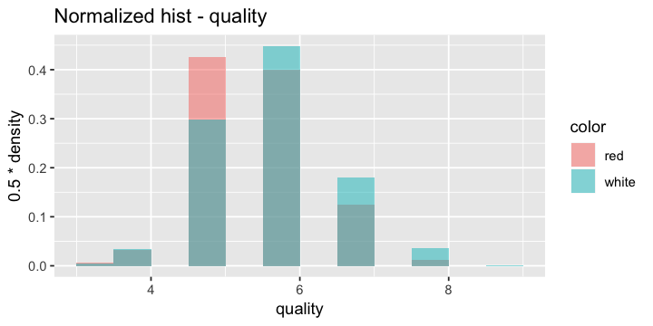

```r
options(repr.plot.width=6, repr.plot.height=3)
ggplot( data = data, aes(quality, fill=color) ) +
  geom_histogram(aes(y=0.5*..density..), breaks = seq(3,9,0.5), alpha=0.5, position="identity") + ggtitle("Normalized hist - quality")
```

- Both distirbutions are centered around 5.5.
- There is an imbalance problem. Maybe group (3,4) and (8,9)

```r
# Histogram plotting function to compare red and white wine
# Bins integrate to 1. This normalization allows easy comparison
hist <- function(var,title, bns , hue) {
options(repr.plot.width=6, repr.plot.height=3)
mx <- max(var)
mn <- min(var)
sep <-  (mx-mn)/bns
ggplot( data = data, aes(var, fill=hue) ) +
  geom_histogram(aes(y=0.5*..density..), breaks = seq(mn, mx, sep), alpha=0.5, position="identity")+ ggtitle(title)

}
```

```r
hist_box<- function(var,title, bns , hue) {
options(repr.plot.width=8, repr.plot.height=3)
mx <- max(var)
mn <- min(var)
sep <-  (mx-mn)/bns
p1<- ggplot( data = data, aes(var, fill=hue) ) +
  geom_histogram(aes(y=0.5*..density..), breaks = seq(mn, mx, sep), alpha=0.5, position="identity")+ ggtitle(title)

p2<- qplot(x = color, y = var, data = data, geom = "boxplot")+ ggtitle('Boxplot')

multiplot(p1, p2, cols=2)



}
```

## 1.- Fixed acidity (tartaric acid - g / dm^3)

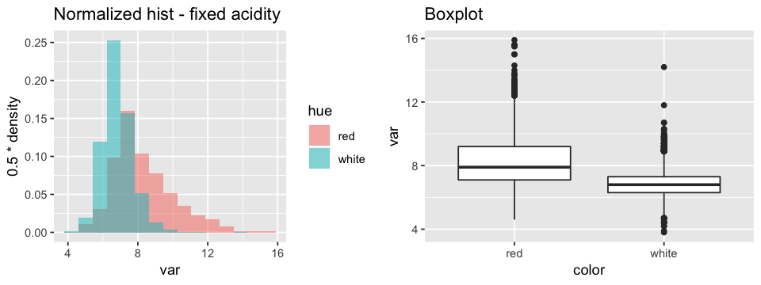

```r
hist_box(data$fixed.acidity,"Normalized hist - fixed acidity ",15, data$color)
```

```r
sum(data$fixed.acidity>14)
```

9

## 2.- volatile acidity (acetic acid - g / dm^3)

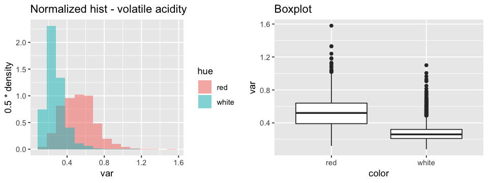

```r
hist_box(data$volatile.acidity,"Normalized hist - volatile acidity ", 15, data$color)
```

```r
sum(data$volatile.acidity>1.2)
```

4

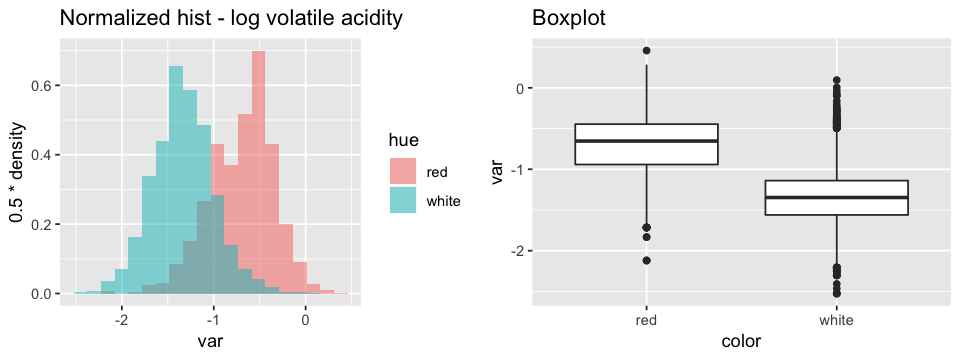

```r
hist_box(log(data$volatile.acidity),"Normalized hist - log volatile acidity ", 20, data$color)
```

## 3.- citric acid

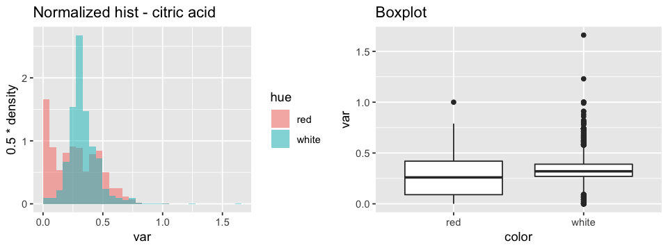

```r
hist_box(data$citric.acid,"Normalized hist - citric acid ",30, data$color)
```

```r
sum(data$citric.acid>0.8)
```

17

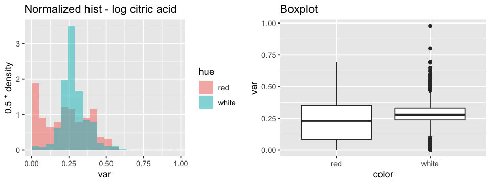

```r
hist_box(log1p((data$citric.acid)),"Normalized hist - log citric acid ",20, data$color)
```

- There are outliers
- Red/white distributons are different. Re does not look unimodal

```r
#Plenty of entries with zero value
sum(data$citric.acid >0.74)
```

29

## 4.- residual sugar (g / dm^3)

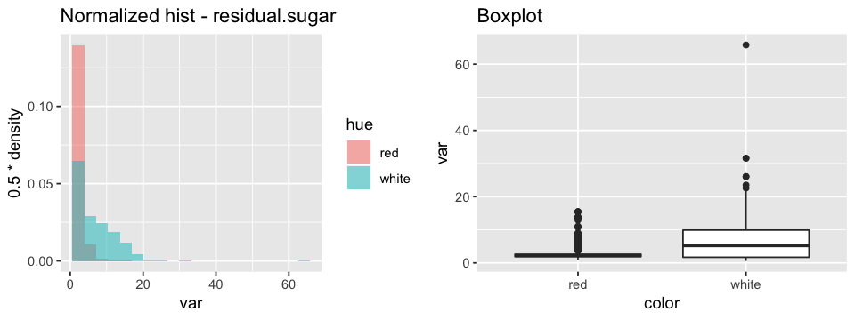

```r
hist_box(data$residual.sugar,"Normalized hist - residual.sugar ",20, data$color)
```

```r
sum(data$residual.sugar >25)
```

5

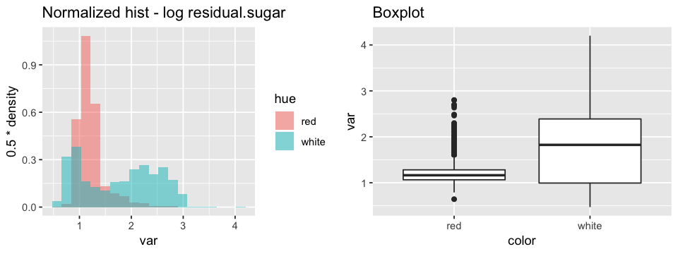

```r
hist_box(log1p(data$residual.sugar),"Normalized hist - log residual.sugar ",20, data$color)
```

## 5.- chlorides (sodium chloride - g / dm^3)

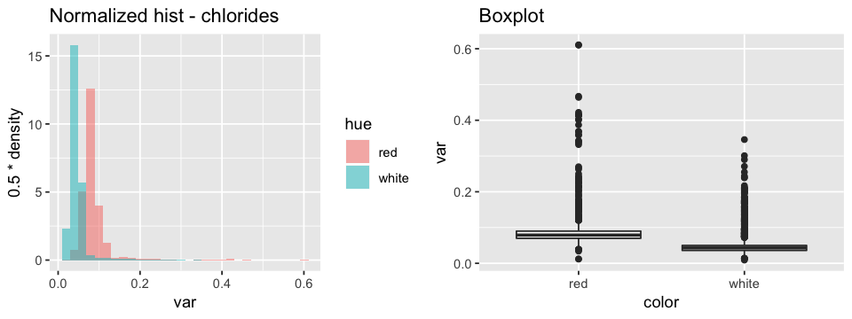

```r
hist_box(data$chlorides,"Normalized hist - chlorides",30, data$color)
```

```r
sum(data$chlorides >0.2)
```

58

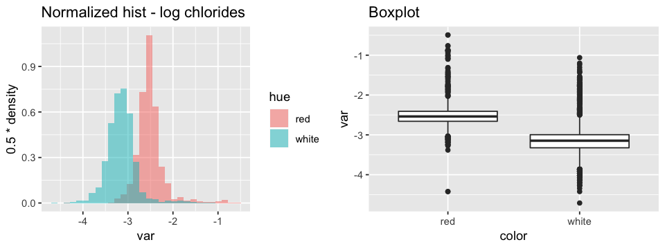

```r
hist_box(log(data$chlorides),"Normalized hist - log chlorides",30, data$color)
```

## 6 - free sulfur dioxide

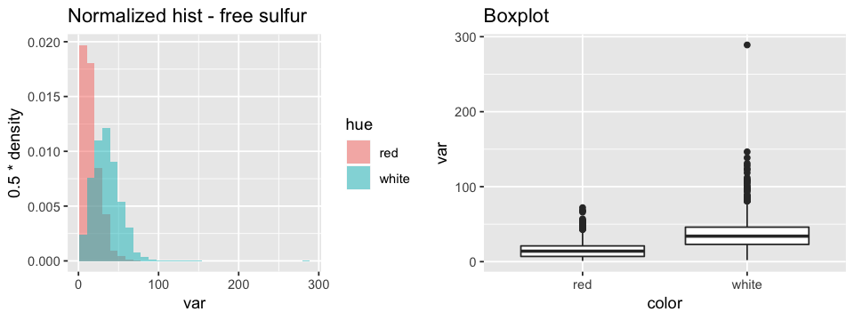

```r
hist_box(data$free.sulfur.dioxide,"Normalized hist - free sulfur",30, data$color)
```

```r
sum(data$free.sulfur.dioxide>100)
```

17

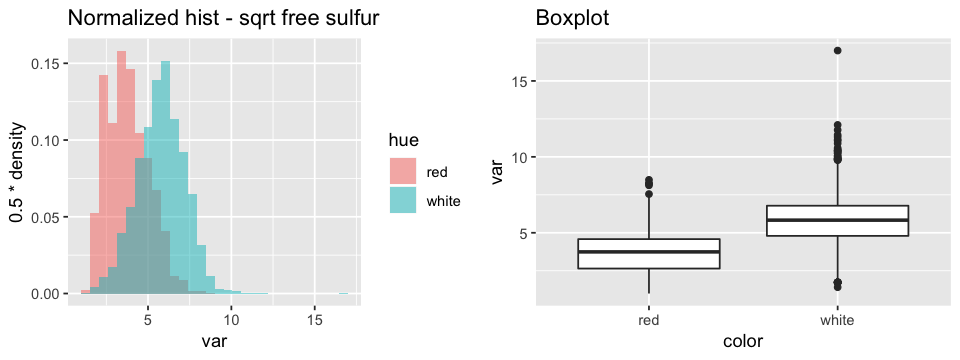

```r
hist_box((data$free.sulfur.dioxide)**(1/2),"Normalized hist - sqrt free sulfur",30, data$color)
```

## 7 -total sulfur dioxide

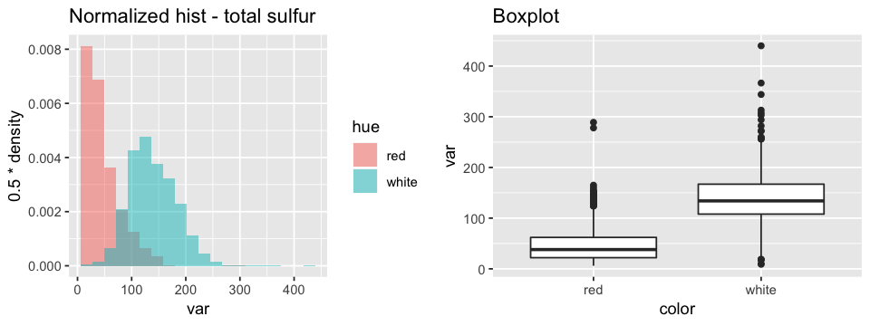

```r
hist_box(data$total.sulfur.dioxide,"Normalized hist - total sulfur",20, data$color)
```

```r
sum(data$total.sulfur.dioxide>300)
```

6

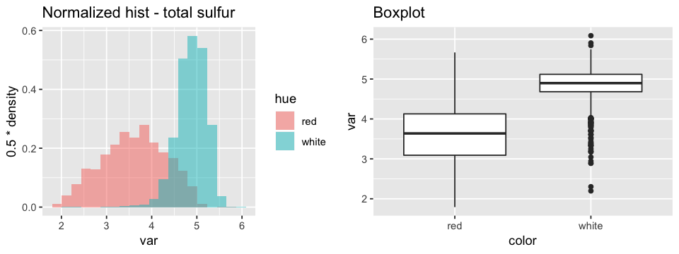

```r
hist_box(log(data$total.sulfur.dioxide),"Normalized hist - total sulfur",20, data$color)
```

## 8 - density

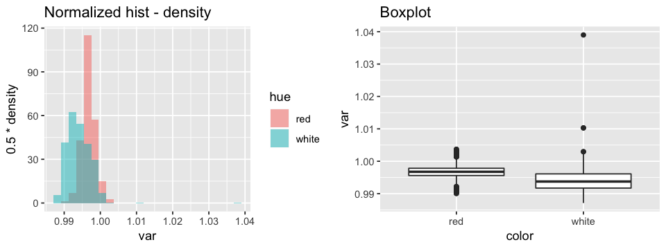

```r
hist_box(data$density,"Normalized hist - density",25, data$color)
```

```r
sum(data$density >1.01)
```

3

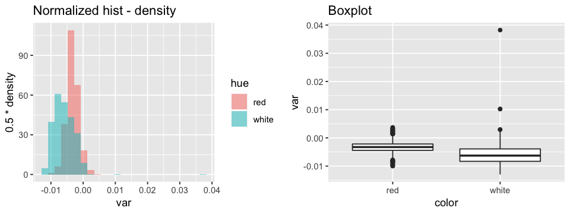

```r
hist_box(log(data$density),"Normalized hist - density",25, data$color)
```

### Clearly the white wine has outliers for total sulfur!

## 9.- pH

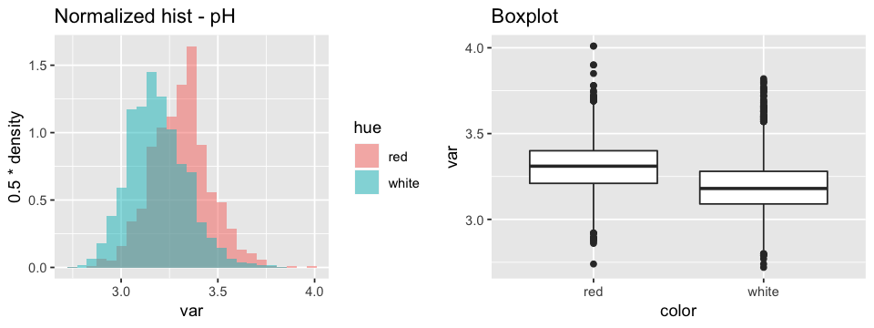

```r
hist_box(data$pH,"Normalized hist - pH",25, data$color)
```

## 10.- sulphates

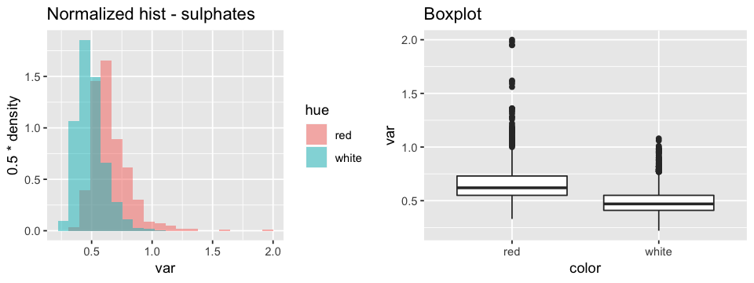

```r
hist_box(data$sulphates,"Normalized hist - sulphates", 20, data$color)
```

```r
sum(data$sulphates>1)
```

61

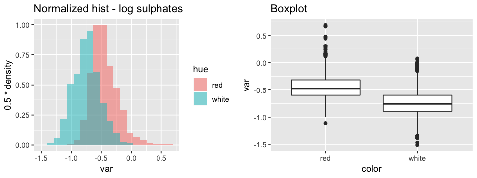

```r
hist_box(log(data$sulphates),"Normalized hist - log sulphates", 20, data$color)
```

## 11 - alcohol (% by volume)

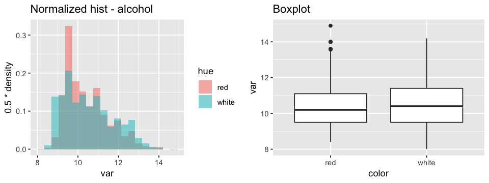

```r
hist_box(data$alcohol,"Normalized hist - alcohol", 20, data$color)
```

```r
sum(data$alcohol>14)
```

3

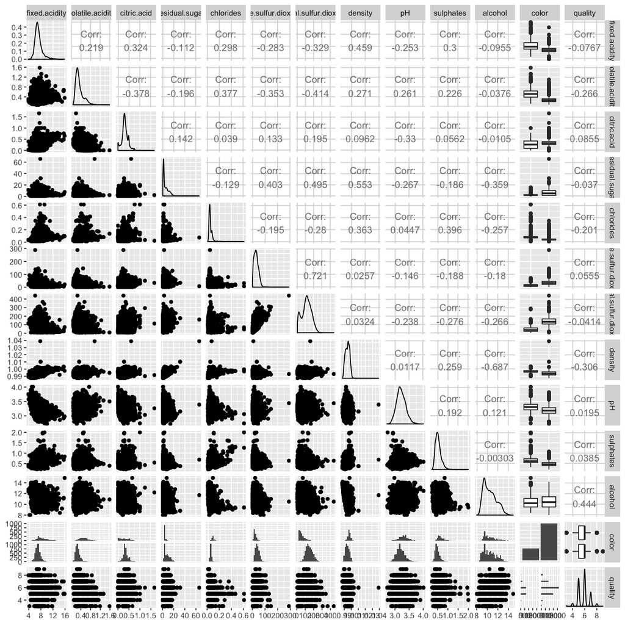

```r
library(GGally)
options(repr.plot.width=10, repr.plot.height=10)
ggpairs(data)
```

```r
# Bins integrate to 1. This normalization allows easy comparison
hist_mod <- function(var,title, bns) {
mx <- max(var)
mn <- min(var)
sep <-  (mx-mn)/bns
print(ggplot( data = data, aes(var, fill=color) ) +
  geom_histogram(aes(y=0.5*..density..), breaks = seq(mn, mx, sep), alpha=0.5, position="identity")+ ggtitle(title))
}
```

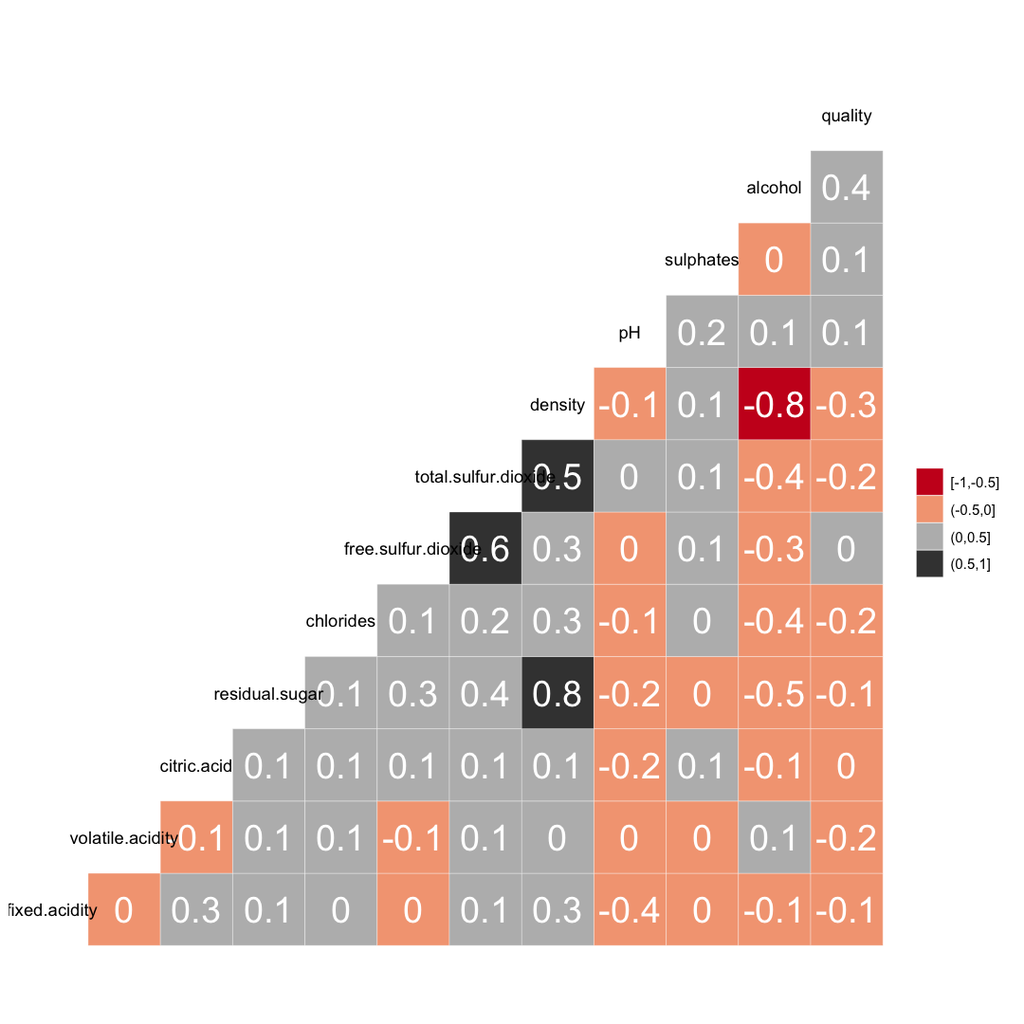

```r
options(repr.plot.width=9, repr.plot.height=9)
ggcorr(white, nbreaks=4, palette='RdGy', label=TRUE, label_size=8, label_color='white')
```

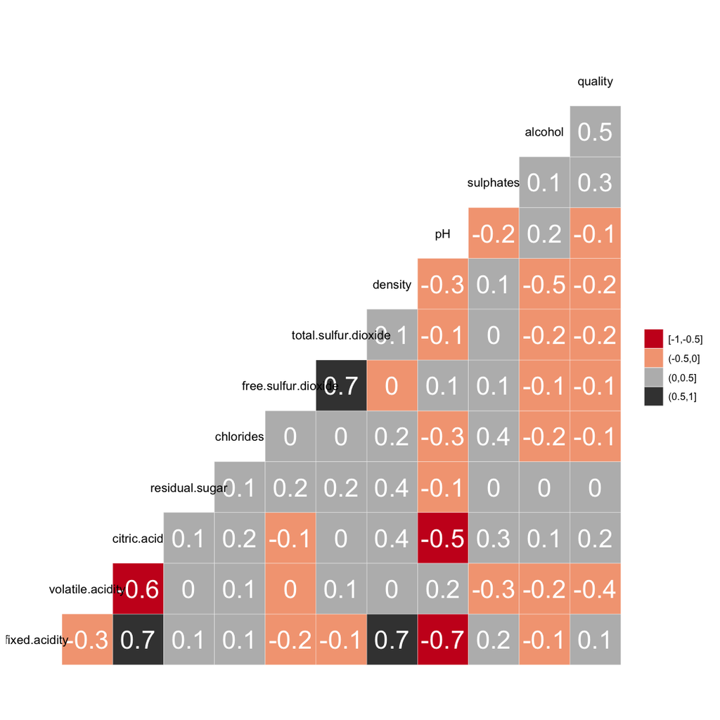

```r
ggcorr(red, nbreaks=4, palette='RdGy', label=TRUE, label_size=8, label_color='white')
```

```r
#cols <- c("X.1","X.2")
#df[cols] <- log(df[cols])
```